# Comparisons of Means

Jean R. Francois

2024-08-01

## ANOVA: Diversity-Productivity

```r
## AOV CWBI
CWBIscore <- cwb_ai %>%
   as.data.frame() %>%
  dplyr::select(TYPE, CWBI, AgIntensity)

CWBIaov <- aov(CWBI ~ TYPE, data = CWBIscore)
summary(CWBIaov)
```

```
##               Df Sum Sq Mean Sq F value Pr(>F)
## TYPE           4  19.37   4.842   80.13 <2e-16 ***
## Residuals   2569 155.22   0.060
## ---
## Signif. codes:  0 '***' 0.001 '**' 0.01 '*' 0.05 '.' 0.1 ' ' 1
## 534 observations deleted due to missingness
```

```r
## Checking assumptions
#1. Check normality of residuals

shapiro.test(residuals(CWBIaov)) # Violated
```

```
##
##  Shapiro-Wilk normality test
##
## data:  residuals(CWBIaov)
## W = 0.98775, p-value = 4.437e-14
```

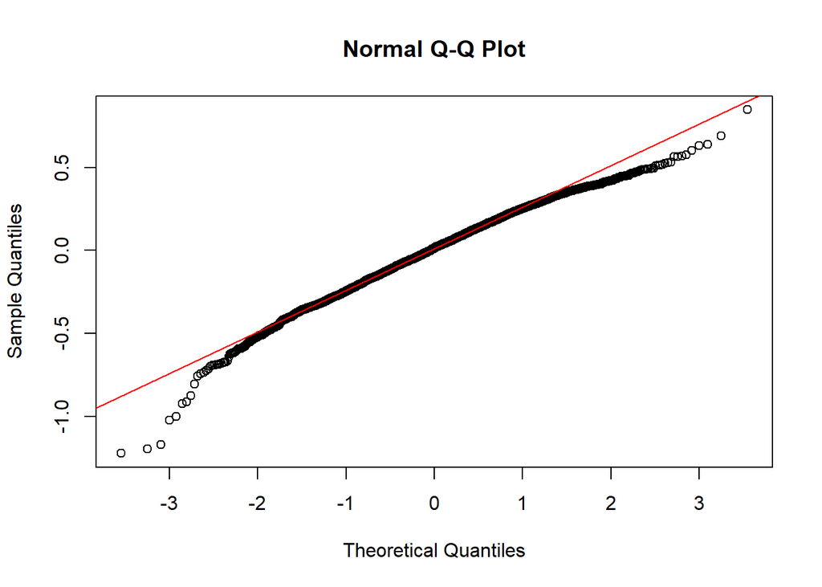

```r
#2. Q-Q plot for residuals
qqnorm(residuals(CWBIaov))
qqline(residuals(CWBIaov), col = "red") # Violated
```

```r
# Check homogeneity of variances
leveneTest(CWBI ~ TYPE, data = CWBIscore) # Violated
```

```
## Levene's Test for Homogeneity of Variance (center = median)
##         Df F value    Pr(>F)
## group    4  5.1723 0.0003776 ***
##       2569
## ---
## Signif. codes:  0 '***' 0.001 '**' 0.01 '*' 0.05 '.' 0.1 ' ' 1
```

```r
bartlett.test(CWBI ~ TYPE, data = CWBIscore) # violated
```

```
##
##  Bartlett test of homogeneity of variances
##
## data:  CWBI by TYPE
## Bartlett's K-squared = 29.11, df = 4, p-value = 7.424e-06
```

## ANOVA: Ag intensity

```r
CWBIaov <- aov(CWBI ~ AgIntensity, data = CWBIscore)
summary(CWBIaov)
```

```
##               Df Sum Sq Mean Sq F value Pr(>F)
## AgIntensity    3   7.11   2.371   35.92 <2e-16 ***
## Residuals   2915 192.40   0.066
## ---
## Signif. codes:  0 '***' 0.001 '**' 0.01 '*' 0.05 '.' 0.1 ' ' 1
## 189 observations deleted due to missingness
```

```r
## Checking assumptions
#1. Check normality of residuals
shapiro.test(residuals(CWBIaov)) # Violated
```

```
##
##  Shapiro-Wilk normality test
##
## data:  residuals(CWBIaov)
## W = 0.98637, p-value = 3.857e-16
```

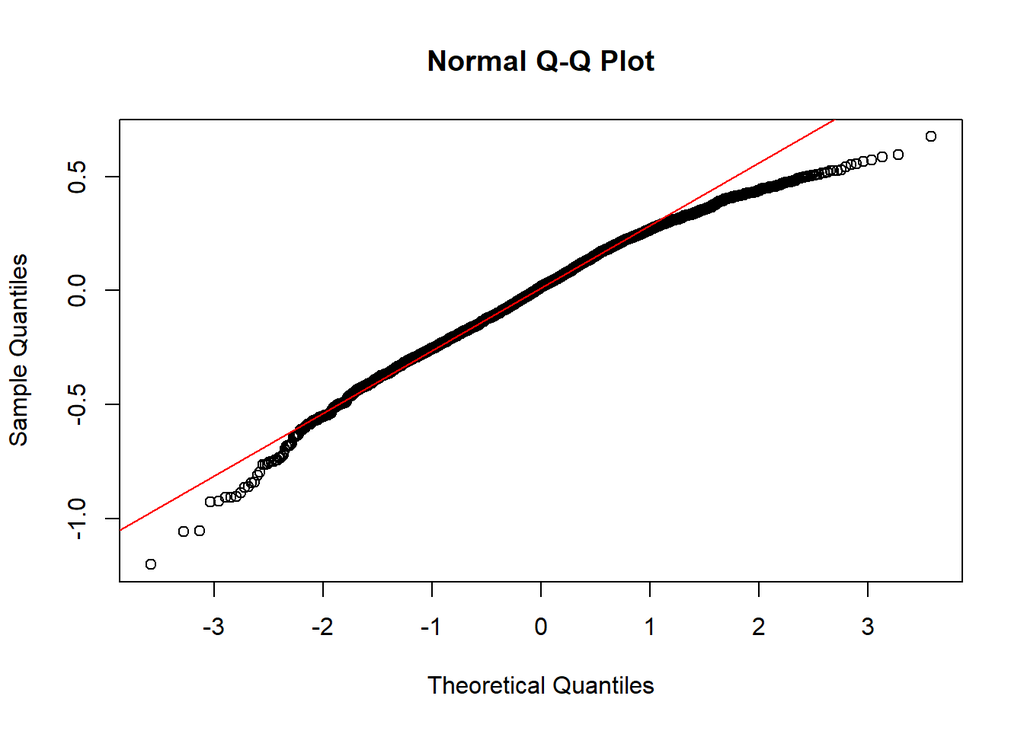

```r
#2. Q-Q plot for residuals
qqnorm(residuals(CWBIaov))
qqline(residuals(CWBIaov), col = "red") # Violated
```

```r
# Check homogeneity of variances
leveneTest(CWBI ~ AgIntensity, data = CWBIscore)
```

```
## Levene's Test for Homogeneity of Variance (center = median)
##         Df F value    Pr(>F)
## group    3  15.712 3.897e-10 ***
##       2915
## ---
## Signif. codes:  0 '***' 0.001 '**' 0.01 '*' 0.05 '.' 0.1 ' ' 1
```

```r
bartlett.test(CWBI ~ AgIntensity, data = CWBIscore) # violated
```

```
##
##  Bartlett test of homogeneity of variances
##
## data:  CWBI by AgIntensity
## Bartlett's K-squared = 38.216, df = 3, p-value = 2.544e-08
```

## Kruskal-Wallis: Diversity-Productivity

```r
# Perform the Kruskal-Wallis test
kruskal_test_result <- kruskal.test(CWBI ~ TYPE, data = CWBIscore)
print(kruskal_test_result)
```

```
##
##  Kruskal-Wallis rank sum test
##
## data:  CWBI by TYPE
## Kruskal-Wallis chi-squared = 287.47, df = 4, p-value < 2.2e-16
```

```r
# Conduct the post-hoc pairwise comparisons
post_hoc_result <- kruskalmc(CWBI ~ TYPE, data = CWBIscore)
print(post_hoc_result)
```

```
## Multiple comparison test after Kruskal-Wallis
## alpha: 0.05
## Comparisons
##                 obs.dif critical.dif stat.signif
## LD-LP-LD-HP    96.90985     132.9807       FALSE
## LD-LP-AVERAGE 123.24447     133.9362       FALSE
## LD-LP-HD-LP   124.03673     147.2926       FALSE
## LD-LP-HD-HP   686.10373     160.8274        TRUE
## LD-HP-AVERAGE 220.15432     109.4075        TRUE
## LD-HP-HD-LP    27.12688     125.4042       FALSE
## LD-HP-HD-HP   783.01358     141.0551        TRUE
## AVERAGE-HD-LP 247.28120     126.4169        TRUE
## AVERAGE-HD-HP 562.85926     141.9562        TRUE
## HD-LP-HD-HP   810.14047     154.6214        TRUE
```

## Kruskal-Wallis: Ag intensity

```r
# Perform the Kruskal-Wallis test
kruskal_test_result <- kruskal.test(CWBI ~ AgIntensity, data = CWBIscore)
print(kruskal_test_result)
```

```
##
##  Kruskal-Wallis rank sum test
##
## data:  CWBI by AgIntensity
## Kruskal-Wallis chi-squared = 110.66, df = 3, p-value < 2.2e-16
```

```r
# Conduct the post-hoc pairwise comparisons
post_hoc_result <- kruskalmc(CWBI ~ AgIntensity, data = CWBIscore)
print(post_hoc_result)
```

```
## Multiple comparison test after Kruskal-Wallis
## alpha: 0.05
## Comparisons
##                          obs.dif critical.dif stat.signif
## FD/AI-FD/Non-AI         240.2377    203.47273        TRUE
## FD/AI-Non-FD/AI         344.0661    174.78236        TRUE
## FD/AI-Non-FD/Non-AI     552.6985    165.05169        TRUE
## FD/Non-AI-Non-FD/AI     103.8284    153.23311       FALSE
## FD/Non-AI-Non-FD/Non-AI 312.4608    142.03370        TRUE
## Non-FD/AI-Non-FD/Non-AI 208.6324     96.54685        TRUE
```

## Kruskal-Wallis: FD/AI

```r
# Perform the Kruskal-Wallis test
kruskal_test_result <- kruskal.test(CWBI ~ TYPE, data = CWBIscore %>% filter(AgIntensity == "FD/AI"))
print(kruskal_test_result)
```

```
##
##  Kruskal-Wallis rank sum test
##
## data:  CWBI by TYPE
## Kruskal-Wallis chi-squared = 55.778, df = 4, p-value = 2.232e-11
```

```r
# Perform the Kruskal-Wallis test
post_hoc_result <- kruskalmc(CWBI ~ TYPE, data = CWBIscore %>% filter(AgIntensity == "FD/AI"))
print(post_hoc_result)
```

```
## Multiple comparison test after Kruskal-Wallis
## alpha: 0.05
## Comparisons
##                  obs.dif critical.dif stat.signif
## LD-LP-LD-HP    22.064655     38.44941       FALSE
## LD-LP-AVERAGE  26.676724     38.44941       FALSE
## LD-LP-HD-LP    29.150641     41.09933       FALSE
## LD-LP-HD-HP    84.375000     51.12893        TRUE
## LD-HP-AVERAGE  48.741379     29.41734        TRUE
## LD-HP-HD-LP    51.215296     32.80514        TRUE
## LD-HP-HD-HP   106.439655     44.73467        TRUE
## AVERAGE-HD-LP   2.473917     32.80514       FALSE
## AVERAGE-HD-HP  57.698276     44.73467        TRUE
## HD-LP-HD-HP    55.224359     47.03178        TRUE
```

## Kruskal-Wallis: FD/Non-AI

```r
# Perform the Kruskal-Wallis test
kruskal_test_result <- kruskal.test(CWBI ~ TYPE, data = CWBIscore %>% filter(AgIntensity == "FD/Non-AI"))
print(kruskal_test_result)
```

```
##
##  Kruskal-Wallis rank sum test
##
## data:  CWBI by TYPE
## Kruskal-Wallis chi-squared = 28.33, df = 4, p-value = 1.069e-05
```

```r
# Perform the Kruskal-Wallis test
post_hoc_result <- kruskalmc(CWBI ~ TYPE, data = CWBIscore %>% filter(AgIntensity == "FD/Non-AI"))
print(post_hoc_result)
```

```
## Multiple comparison test after Kruskal-Wallis
## alpha: 0.05
## Comparisons
##                obs.dif critical.dif stat.signif
## LD-LP-LD-HP   13.19787     41.54290       FALSE
## LD-LP-AVERAGE 19.88658     40.23738       FALSE
## LD-LP-HD-LP   47.52747     34.61183        TRUE
## LD-LP-HD-HP   29.13804     65.98416       FALSE
## LD-HP-AVERAGE 33.08444     45.03955       FALSE
## LD-HP-HD-LP   60.72534     40.09357        TRUE
## LD-HP-HD-HP   15.94017     69.01756       FALSE
## AVERAGE-HD-LP 27.64090     38.73923       FALSE
## AVERAGE-HD-HP 49.02462     68.23970       FALSE
## HD-LP-HD-HP   76.66551     65.08141        TRUE
```

## Kruskal-Wallis: Non-FD/AI

```r
# Perform the Kruskal-Wallis test
kruskal_test_result <- kruskal.test(CWBI ~ TYPE, data = CWBIscore %>% filter(AgIntensity == "Non-FD/AI"))
print(kruskal_test_result)
```

```
##
##  Kruskal-Wallis rank sum test
##
## data:  CWBI by TYPE
## Kruskal-Wallis chi-squared = 205.05, df = 4, p-value < 2.2e-16
```

```r
# Perform the Kruskal-Wallis test
post_hoc_result <- kruskalmc(CWBI ~ TYPE, data = CWBIscore %>% filter(AgIntensity == "Non-FD/AI"))
print(post_hoc_result)
```

```
## Multiple comparison test after Kruskal-Wallis
## alpha: 0.05
## Comparisons
##                 obs.dif critical.dif stat.signif
## LD-LP-LD-HP    89.10614    102.06485       FALSE
## LD-LP-AVERAGE  86.80000    103.56713       FALSE
## LD-LP-HD-LP    32.75982    111.44075       FALSE
## LD-LP-HD-HP   212.35456    107.74563        TRUE
## LD-HP-AVERAGE 175.90614     54.23496        TRUE
## LD-HP-HD-LP   121.86596     68.07585        TRUE
## LD-HP-HD-HP   301.46069     61.84173        TRUE
## AVERAGE-HD-LP  54.04018     70.30817       FALSE
## AVERAGE-HD-HP 125.55456     64.29088        TRUE
## HD-LP-HD-HP   179.59473     76.32960        TRUE
```

## Kruskal-Wallis: Non-FD/Non-AI

```r
# Perform the Kruskal-Wallis test
kruskal_test_result <- kruskal.test(CWBI ~ TYPE, data = CWBIscore %>% filter(AgIntensity == "Non-FD/Non-AI"))
print(kruskal_test_result)
```

```
##
##  Kruskal-Wallis rank sum test
##
## data:  CWBI by TYPE
## Kruskal-Wallis chi-squared = 125.75, df = 4, p-value < 2.2e-16
```

```r
# Perform the Kruskal-Wallis test
post_hoc_result <- kruskalmc(CWBI ~ TYPE, data = CWBIscore %>% filter(AgIntensity == "Non-FD/Non-AI"))
print(post_hoc_result)
```

```
## Multiple comparison test after Kruskal-Wallis
## alpha: 0.05
## Comparisons
##                 obs.dif critical.dif stat.signif
## LD-LP-LD-HP   118.97672     89.36548        TRUE
## LD-LP-AVERAGE  84.94138     88.93393       FALSE
## LD-LP-HD-LP    63.44670    101.46261       FALSE
## LD-LP-HD-HP   358.02784    110.93171        TRUE
## LD-HP-AVERAGE  34.03535     78.29392       FALSE
## LD-HP-HD-LP   182.42342     92.27868        TRUE
## LD-HP-HD-HP   239.05111    102.59892        TRUE
## AVERAGE-HD-LP 148.38808     91.86082        TRUE
## AVERAGE-HD-HP 273.08646    102.22325        TRUE
## HD-LP-HD-HP   421.47454    113.29170        TRUE
```

## Regression

### Without interactions

```r
regCWBI <- cwb_ai %>%
  dplyr::select(CWBI, TYPE, AgIntensity, FRRName)

# Run the regression
model <- lm(CWBI ~ TYPE + AgIntensity, data = regCWBI)

tab_model(model,
          p.style = "numeric_stars",
          digits = 4,
          digits.p = 3,
          show.se = TRUE,
          show.ci = 0.95)
```

CWBI

Predictors

Estimates

std. Error

CI

p

(Intercept)

3.5857 ***

0.0210

3.5445 – 3.6269

**<0.001**

TYPE [LD-HP]

0.0169

0.0159

-0.0143 – 0.0480

0.288

TYPE [AVERAGE]

-0.0629 ***

0.0159

-0.0941 – -0.0317

**<0.001**

TYPE [HD-LP]

0.0095

0.0172

-0.0242 – 0.0433

0.580

TYPE [HD-HP]

-0.2618 ***

0.0191

-0.2992 – -0.2244

**<0.001**

AgIntensity [FD/Non-AI]

-0.0949 ***

0.0226

-0.1393 – -0.0505

**<0.001**

AgIntensity [Non-FD/AI]

-0.0818 ***

0.0195

-0.1199 – -0.0436

**<0.001**

AgIntensity  
[Non-FD/Non-AI]

-0.1640 ***

0.0184

-0.2000 – -0.1280

**<0.001**

Observations

2454

R<sup>2</sup> / R<sup>2</sup> adjusted

0.154 / 0.152

- p<0.05 ** p<0.01 *** p<0.001

### With interactions

```r
# Run the regression
model <- lm(CWBI ~ TYPE + AgIntensity + TYPE*AgIntensity, data = regCWBI)

tab_model(model,
          p.style = "numeric_stars",
          digits = 4,
          digits.p = 3,
          show.se = TRUE,
          show.ci = 0.95)
```

CWBI

Predictors

Estimates

std. Error

CI

p

(Intercept)

3.6160 ***

0.0471

3.5236 – 3.7084

**<0.001**

TYPE [LD-HP]

0.1128 *

0.0560

0.0029 – 0.2226

**0.044**

TYPE [AVERAGE]

-0.1033

0.0560

-0.2132 – 0.0065

0.065

TYPE [HD-LP]

-0.1419 *

0.0599

-0.2593 – -0.0244

**0.018**

TYPE [HD-HP]

-0.4630 ***

0.0745

-0.6091 – -0.3169

**<0.001**

AgIntensity [FD/Non-AI]

-0.1773 **

0.0543

-0.2838 – -0.0708

**0.001**

AgIntensity [Non-FD/AI]

-0.1061

0.0612

-0.2261 – 0.0138

0.083

AgIntensity  
[Non-FD/Non-AI]

-0.1815 ***

0.0496

-0.2787 – -0.0843

**<0.001**

TYPE [LD-HP] ×  
AgIntensity [FD/Non-AI]

-0.1532 *

0.0711

-0.2926 – -0.0138

**0.031**

TYPE [AVERAGE] ×  
AgIntensity [FD/Non-AI]

0.1560 *

0.0703

0.0182 – 0.2937

**0.026**

TYPE [HD-LP] ×  
AgIntensity [FD/Non-AI]

0.2551 ***

0.0701

0.1177 – 0.3926

**<0.001**

TYPE [HD-HP] ×  
AgIntensity [FD/Non-AI]

0.3277 **

0.1019

0.1279 – 0.5275

**0.001**

TYPE [LD-HP] ×  
AgIntensity [Non-FD/AI]

-0.0030

0.0699

-0.1400 – 0.1341

0.966

TYPE [AVERAGE] ×  
AgIntensity [Non-FD/AI]

-0.0321

0.0702

-0.1699 – 0.1056

0.647

TYPE [HD-LP] ×  
AgIntensity [Non-FD/AI]

0.0935

0.0753

-0.0541 – 0.2411

0.214

TYPE [HD-HP] ×  
AgIntensity [Non-FD/AI]

0.1475

0.0866

-0.0223 – 0.3172

0.089

TYPE [LD-HP] ×  
AgIntensity  
[Non-FD/Non-AI]

-0.1830 **

0.0594

-0.2995 – -0.0666

**0.002**

TYPE [AVERAGE] ×  
AgIntensity  
[Non-FD/Non-AI]

0.0565

0.0594

-0.0599 – 0.1729

0.341

TYPE [HD-LP] ×  
AgIntensity  
[Non-FD/Non-AI]

0.1639 *

0.0639

0.0385 – 0.2892

**0.010**

TYPE [HD-HP] ×  
AgIntensity  
[Non-FD/Non-AI]

0.2414 **

0.0784

0.0877 – 0.3952

**0.002**

Observations

2454

R<sup>2</sup> / R<sup>2</sup> adjusted

0.214 / 0.208

- p<0.05 ** p<0.01 *** p<0.001

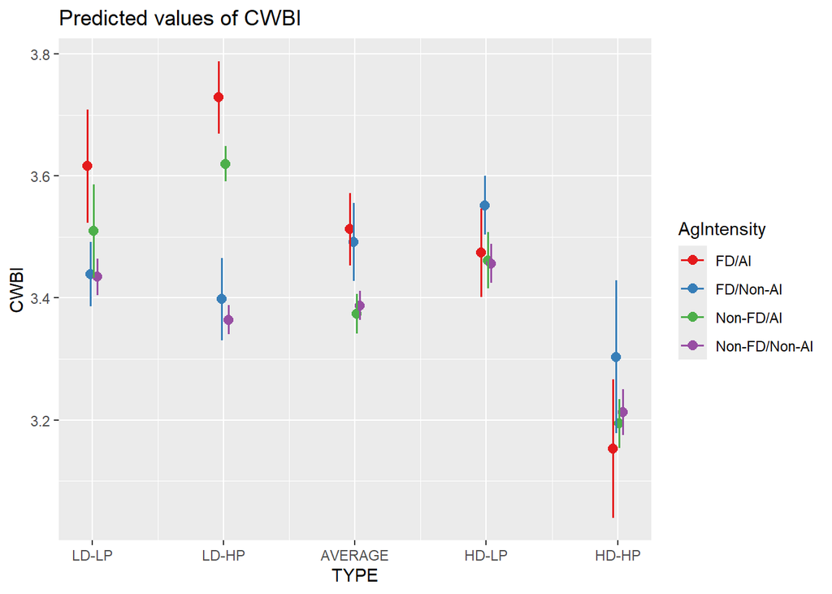

```r
plot_model(model, type = "int")
```

### Adding FRR

```r
model <- lm(CWBI ~ TYPE + AgIntensity + TYPE*AgIntensity + FRRName, data = regCWBI)

tab_model(model,
          p.style = "numeric_stars",
          digits = 4,
          digits.p = 3,
          show.se = TRUE,
          show.ci = 0.95)
```

CWBI

Predictors

Estimates

std. Error

CI

p

(Intercept)

3.5962 ***

0.0451

3.5079 – 3.6846

**<0.001**

TYPE [LD-HP]

0.1018 *

0.0491

0.0054 – 0.1982

**0.038**

TYPE [AVERAGE]

-0.0523

0.0497

-0.1497 – 0.0451

0.293

TYPE [HD-LP]

-0.1379 *

0.0539

-0.2435 – -0.0322

**0.011**

TYPE [HD-HP]

-0.2968 ***

0.0660

-0.4263 – -0.1673

**<0.001**

AgIntensity [FD/Non-AI]

-0.1399 **

0.0478

-0.2337 – -0.0461

**0.003**

AgIntensity [Non-FD/AI]

-0.1176 *

0.0537

-0.2229 – -0.0123

**0.029**

AgIntensity  
[Non-FD/Non-AI]

-0.1374 **

0.0439

-0.2234 – -0.0514

**0.002**

FRRName [Eastern Uplands]

-0.1608 ***

0.0197

-0.1994 – -0.1221

**<0.001**

FRRName [Fruitful Rim]

-0.1506 ***

0.0237

-0.1969 – -0.1042

**<0.001**

FRRName [Heartland]

0.0456 *

0.0200

0.0065 – 0.0848

**0.022**

FRRName [Mississippi  
Portal]

-0.3161 ***

0.0242

-0.3636 – -0.2685

**<0.001**

FRRName [Northern  
Crescent]

0.1553 ***

0.0208

0.1144 – 0.1961

**<0.001**

FRRName [Northern Great  
Plains]

0.0897 ***

0.0243

0.0420 – 0.1374

**<0.001**

FRRName [Prairie Gateway]

-0.0512 *

0.0202

-0.0908 – -0.0117

**0.011**

FRRName [Southern  
Seaboard]

-0.1464 ***

0.0200

-0.1857 – -0.1071

**<0.001**

TYPE [LD-HP] ×  
AgIntensity [FD/Non-AI]

-0.0644

0.0629

-0.1877 – 0.0590

0.306

TYPE [AVERAGE] ×  
AgIntensity [FD/Non-AI]

0.0921

0.0620

-0.0295 – 0.2138

0.137

TYPE [HD-LP] ×  
AgIntensity [FD/Non-AI]

0.2092 ***

0.0617

0.0882 – 0.3301

**0.001**

TYPE [HD-HP] ×  
AgIntensity [FD/Non-AI]

0.2378 **

0.0897

0.0619 – 0.4137

**0.008**

TYPE [LD-HP] ×  
AgIntensity [Non-FD/AI]

0.0066

0.0613

-0.1136 – 0.1267

0.915

TYPE [AVERAGE] ×  
AgIntensity [Non-FD/AI]

-0.0128

0.0617

-0.1339 – 0.1083

0.836

TYPE [HD-LP] ×  
AgIntensity [Non-FD/AI]

0.0988

0.0664

-0.0313 – 0.2290

0.137

TYPE [HD-HP] ×  
AgIntensity [Non-FD/AI]

0.1466

0.0759

-0.0021 – 0.2954

0.053

TYPE [LD-HP] ×  
AgIntensity  
[Non-FD/Non-AI]

-0.1119 *

0.0521

-0.2141 – -0.0096

**0.032**

TYPE [AVERAGE] ×  
AgIntensity  
[Non-FD/Non-AI]

0.0622

0.0528

-0.0413 – 0.1657

0.238

TYPE [HD-LP] ×  
AgIntensity  
[Non-FD/Non-AI]

0.1145 *

0.0568

0.0031 – 0.2258

**0.044**

TYPE [HD-HP] ×  
AgIntensity  
[Non-FD/Non-AI]

0.1870 **

0.0691

0.0516 – 0.3225

**0.007**

Observations

2454

R<sup>2</sup> / R<sup>2</sup> adjusted

0.400 / 0.393

- p<0.05 ** p<0.01 *** p<0.001

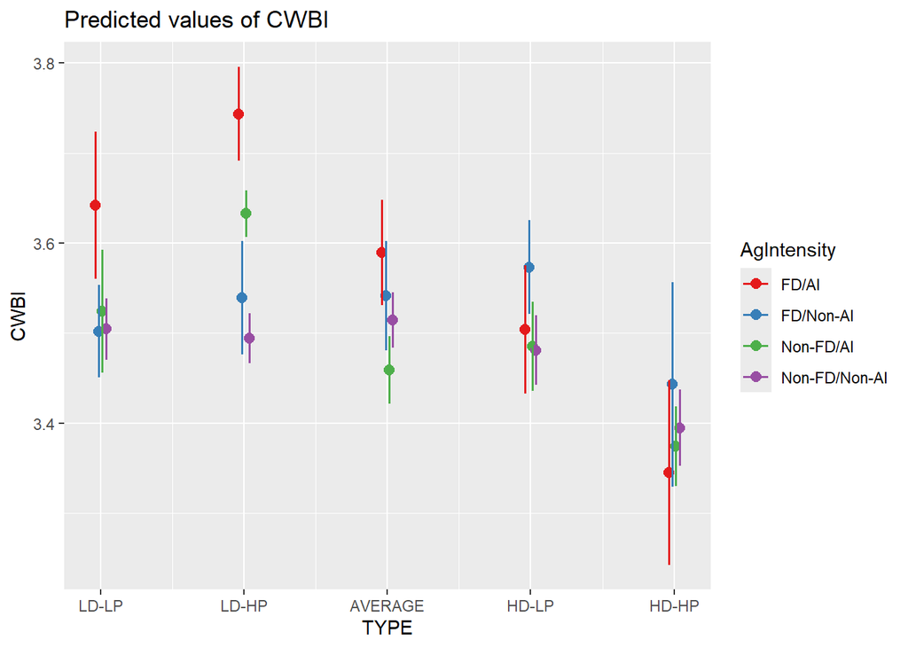

```r
plot_model(model, type = "int")
```